# Factors Associated with Survival on the Titanic

Sean Schilk

10/25/2025

# 1 Titanic Survival Prediction with Logistic Regression

This week’s assignment focuses on binary predictive modeling using the logistic regression model. We will use a data set provided by Kaggle during a competition challenge.

```r
library(readr)
titanic = read_csv("https://sschilk.github.io/Topics-In-Advanced-Statistics/datasets/train.csv")
```

There are 12 variables in the data set:

survival: Survival 0 = No, 1 = Yes pclass: Ticket class 1 = 1st, 2 = 2nd, 3 = 3rd sex: Sex Age: Age in years  
sibsp: # of siblings / spouses aboard the Titanic  
parch: # of parents / children aboard the Titanic  
ticket: Ticket number  
fare: Passenger fare  
cabin: Cabin number  
embarked: Port of Embarkation C = Cherbourg, Q = Queenstown, S = Southampton

Our response here is survival, whether the individual survived the titanic sinking or not.

```r
titanic <- na.omit(titanic)  # Delete all records with missing components
titanic$PassengerId <- NULL
titanic$Name <- NULL
titanic$Ticket <- NULL
titanic$Cabin <- NULL
#remove all ID variables
head(titanic)
```

```
# A tibble: 6 × 8
  Survived Pclass Sex      Age SibSp Parch  Fare Embarked
     <dbl>  <dbl> <chr>  <dbl> <dbl> <dbl> <dbl> <chr>
1        1      1 female    38     1     0  71.3 C
2        1      1 female    35     1     0  53.1 S
3        0      1 male      54     0     0  51.9 S
4        1      3 female     4     1     1  16.7 S
5        1      1 female    58     0     0  26.6 S
6        1      2 male      34     0     0  13   S
```

# 2 Research Question

The objective of this case study is to build a logistic regression model to predict which passengers survived the Titanic shipwreck.

# 3 Exploratory Data Analysis

We first make the following pairwise scatter plots to inspect the potential issues with predictor variables.

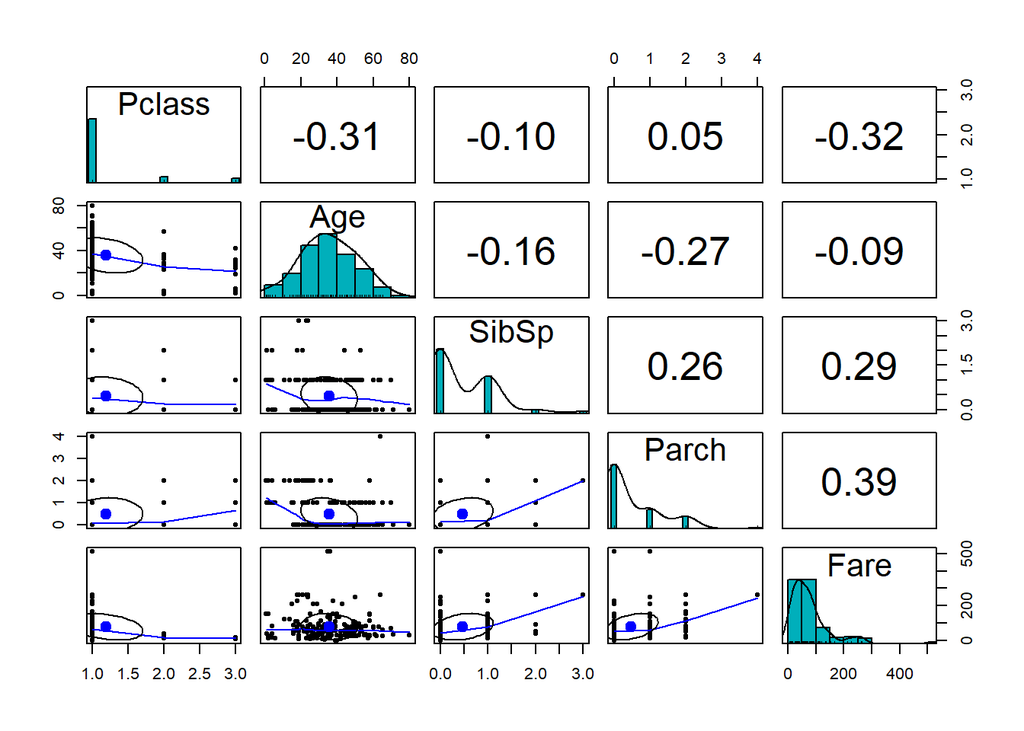

```r
library(psych)
pairs.panels(titanic[,-c(1,3,8)],
             method = "pearson", # correlation method
             hist.col = "#00AFBB",
             density = TRUE,  # show density plots
             ellipses = TRUE # show correlation ellipses
             )
```

Fare is significantly skewed, so we discretize in the following:

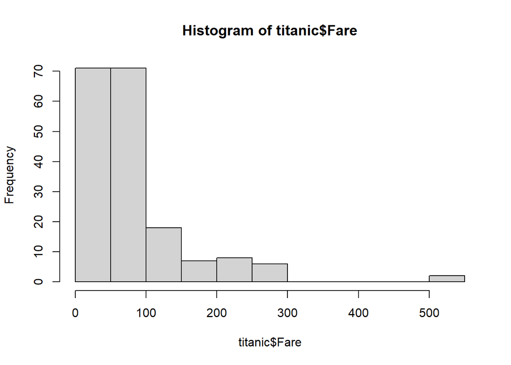

```r
hist(titanic$Fare)
```

```r
fare = titanic$Fare
grp.fare = fare
grp.fare[fare >= 0 & fare <= 100] <- "0:100"
grp.fare[fare > 101 & fare <= 200] <- "101:200"
grp.fare[fare > 200] <- "200+"
titanic$grp.fare = grp.fare
table(titanic$grp.fare)
```

```
  0:100 101:200    200+
    142      25      16
```

There weren’t any high correlations, so no need to standardize numerical predictor variables.

# 4 Data Split - Training and Testing Data

We randomly split the data into two subsets. 80% of the data will be used as training data. We will use the training data to search the candidate models, validate them and identify the final model using the cross-validation method. The 20% of the hold-up sample will be used for assessing the performance of the final model.

```r
set.seed(2)
## splitting data: 80% training and 20% testing
n <- dim(titanic)[1]
train.n <- round(0.8*n)
train.id <- sample(1:n, train.n, replace = FALSE)
## training and testing data sets
train <- titanic[train.id, ]
test <- titanic[-train.id, ]
```

# 5 Best Model Specification

In the previous module, we introduced full and reduced models to set up the scope for searching for the final model. In this case study, we use the full, reduced, and final models obtained based on the step-wise variable selection as the three candidate models.

# 6 Cross Validation for Model Identification

Since our training data is relatively small, I will use 5-fold cross-validation to ensure the validation data set has enough surviving cases.

```r
set.seed(1)
library(pander)
## 5-fold cross-validation
k=5
## floor() function must be used to avoid producing NA in the subsequent results
fold.size = floor(dim(train)[1]/k)
## PE vectors for candidate models
PE1 = rep(0,5)
PE2 = rep(0,5)
PE3 = rep(0,5)
for(i in 1:k){
  ## Training and testing folds
  valid.id = (fold.size*(i-1)+1):(fold.size*i)
  valid = train[valid.id, ]
  train.dat = train[-valid.id,]
  # full model
  candidate01 = glm(Survived ~.,
                    family = binomial(link = "logit"),
                    data = train.dat)
  ## reduced model
  candidate03 = glm(Survived ~ Age,
                    family = binomial(link = "logit"),
                    data = train.dat)
  ## step wise model
  candidate02 = stepAIC(candidate01,
                      scope = list(lower=formula(candidate03),upper=formula(candidate01)),
                      direction = "forward",   # forward selection
                      trace = 0                # do not show the details
                      )
##  predicted probabilities of each candidate model
   pred01 = predict(candidate01, newdata = valid, type="response")
   pred02 = predict(candidate02, newdata = valid, type="response")
   pred03 = predict(candidate03, newdata = valid, type="response")

   pre.outcome01 = ifelse((pred01) > 0.4, 1, 0)
   pre.outcome02 = ifelse((pred02) > 0.4, 1, 0)
   pre.outcome03 = ifelse((pred03) > 0.4, 1, 0)
   PE1[i] = 1-sum(pre.outcome01 == as.vector(valid$Survived))/length(pred01)
   PE2[i] = 1-sum(pre.outcome02 == as.vector(valid$Survived))/length(pred02)
   PE3[i] = 1-sum(pre.outcome03 == as.vector(valid$Survived))/length(pred03)
}
avg.pe = cbind(PE.1 = mean(PE1), PE.2 = mean(PE2), PE.3 = mean(PE3))
pander(avg.pe, caption = "Average of prediction errors of candidate models")
```

Average of prediction errors of candidate models

| PE.1 | PE.2 | PE.3 |
| --- | --- | --- |
| 0.2621 | 0.2621 | 0.2966 |

The average predictive errors show that candidate models 1 and 2 have the same predictive error. Since model 2 is simpler than model 1, we choose model 2 as the final predictive model. This selection of the final model is based on the cut-off probability 0.4.

# 7 Final Model Reporting

The previous cross-validation procedure identified the best model with pre-selected cut-off 0.4. The actual accuracy to be report to the client MUST be based on the withheld test data. Therefore, the actual accuracy of the final model is given by

```r
pred02 = predict(candidate02, newdata = test, type="response")
pred02.outcome = ifelse(as.vector(pred02)>0.5, 1, 0)

accuracy = sum(pred02.outcome == test$Survived)/length(pred02)
pander(accuracy, caption="The actual accuracy of the final model")
```

*0.5676* Therefore, the final model has an accuracy rate given in the above table.

Since we used a random split method to define the training and testing data when re-running the code, the performance metrics will be slightly different.

# 8 ROC Analysis - Global Performance

The ROC curve as a visual tool is used to compare the global performance of binary predictive models. Since it is used for the purpose of model selection, we need to construct ROC curves based on the training data. Next, we will construct ROC curves and calculate the corresponding AUCs using package pROC.

We first estimate the TPR (true positive rate, sensitivity) and FPR (false positive rate, 1 - specificity) at each cut-off probability for each of the three candidate models using the following R function.

```r
## A function to extract false positive and false negative rates
TPR.FPR=function(pred){
  prob.seq = seq(0,1, length=50)  # 50 equally spaced cut-off probabilities
  pn=length(prob.seq)
  true.lab=as.vector(train$Survived)
  TPR = NULL
  FPR = NULL
  ##
  for (i in 1:pn){
   pred.lab = as.vector(ifelse(pred >prob.seq[i],1, 0))
   TPR[i] = length(which(true.lab==1 & pred.lab==1))/length(which(true.lab==1))
   FPR[i] = length(which(true.lab==0 & pred.lab==1))/length(which(true.lab==0))
  }
 cbind(FPR = FPR, TPR = TPR)
}
```

The ROC curves of the three candidate models are given below.

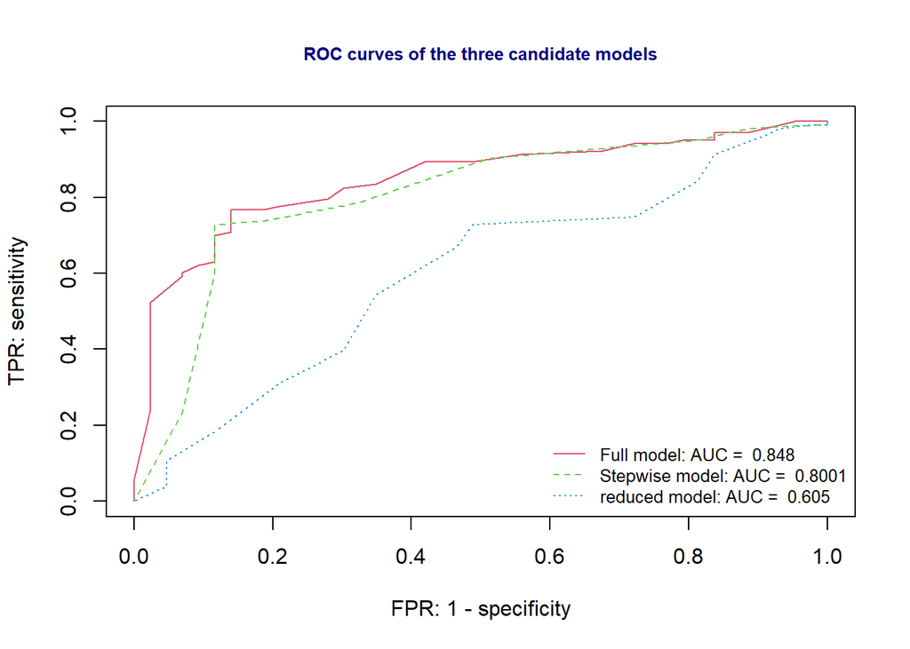

```r
## we need a function to calculate the AUC.
if (!require("pROC")) {
   install.packages("pROC")
   library(pROC)
}
##  candidate models
##  full model
candidate01 = glm(Survived ~Pclass + Sex +Age+ SibSp + Parch +
                    grp.fare + Embarked, family = binomial(link = "logit"),
                    data = train)
## reduced model
candidate03 = glm(Survived ~ Age,
                    family = binomial(link = "logit"),
                    data = train)
##
candidate02 = stepAIC(candidate03,
                      scope = list(lower=formula(candidate03),upper=formula(candidate01)),
                      direction = "forward",   # forward selection
                      trace = 0                # do not show the details
                      )
##  predicted probabilities
pred01 = predict.glm(candidate01, newdata = train, type="response")
pred02 = predict.glm(candidate02, newdata = train, type="response")
pred03 = predict.glm(candidate03, newdata = train, type="response")
####
## ROC curve
 plot(TPR.FPR(pred01)[,1], TPR.FPR(pred01)[,2],
      type="l", col=2, lty=1, xlim=c(0,1), ylim=c(0,1),
      xlab = "FPR: 1 - specificity",
      ylab ="TPR: sensitivity",
      main = "ROC curves of the three candidate models",
      cex.main = 0.8,
      col.main = "navy")
 lines(TPR.FPR(pred02)[,1], TPR.FPR(pred02)[,2],  col=3, lty=2)
 lines(TPR.FPR(pred03)[,1], TPR.FPR(pred03)[,2],  col=4, lty=3)

  ##
  category = train$Survived == 1
  ROCobj01 <- roc(category, as.vector(pred01))
  ROCobj02 <- roc(category, as.vector(pred02))
  ROCobj03 <- roc(category, as.vector(pred03))
  AUC01 = round(auc(ROCobj01),4)
  AUC02 = round(auc(ROCobj02),4)
  AUC03 = round(auc(ROCobj03),4)
  ##
  legend("bottomright", c(paste("Full model: AUC = ",AUC01),
                         paste("Stepwise model: AUC = ",AUC02),
                         paste("reduced model: AUC = ", AUC03)),
        col=2:4, lty=1:3, cex = 0.8, bty="n")
```

We can see from the ROC curve that full model and the stepwise model are better than the reduced model. However, the full model and the stepwise model have similar ROC curve and AUCs, with the full model having a slight edge.

Therefore if you want a simpler model go I would recommend the stepwise model, although you would be trading some accuracy that could be found in the full model.

```r
pred02 = predict(candidate01, newdata = test, type="response")
pred02.outcome = ifelse(as.vector(pred02)>0.5, 1, 0)

accuracy = sum(pred02.outcome == test$Survived)/length(pred02)
pander(accuracy, caption="The actual accuracy of the final model")
```

[output not shown]